# Alzheimer’s Detection Using Handwriting Analysis

Braeden Cullen

April 29th, 2024

# Introduction and Problem Statement

10% of all people over the age of 65 have Alzheimer’s disease, and as many as 50% of people over 85 have it. The number of people with the disease doubles every 5 years beyond age 65. Alzheimer’s is a progressive neurodegenerative disease that affects millions of people worldwide. It is the most common cause of dementia and is characterized by memory loss, cognitive decline, and behavioral changes. The disease is currently incurable, but early detection can help slow its progression and improve the quality of life for affected individuals. Someone in the United States develops Alzheimer’s disease every 65 seconds, and it is the sixth leading cause of death in the country. The cost of caring for people with Alzheimer’s and other dementias is estimated to be 305 billion in 2020, and this number is expected to rise to 1.1 trillion by 2050. The disease is a major public health concern, and there is an urgent need for effective diagnostic tools and treatments. Early stage Alzheimer’s detection, in particular, is crucial for developing interventions that can slow or stop the progression of the disease. The goal of this project is to develop a model that can predict whether a person has Alzheimer’s disease based on features extracted from handwriting tasks. The model will be trained on a dataset containing patients with Alzheimer’s disease and healthy controls. This model will be evaluated on its ability to accurately classify unseen patients as either having or not having the disease. The model will be used to identify risk factors for Alzheimer’s disease and to develop a predictive tool that can help clinicians diagnose the disease in its early stages.We hypothesize that early-stage Alzheimer’s can be effectively detected through graphological analysis of patient handwriting data. We estimate that most effective indicators of early-stage Alzheimer’s will likely be related to the size, shape, and speed of the handwriting, as well as the number of pen lifts and pen strokes.

# Data Overview and Visualization

## Data Preprocessing

```r
# Load the data
data <- read.csv("darwin.csv")

# Convert class into binary
data$class <- ifelse(data$class == "P", 1, 0)

# Data diagnosis column
data_outcomes <- data %>% select(452)

# Select first handwritten task only
train_data <- data %>% select(1:18)
train_data_outcomes <- data_outcomes
train_data <- train_data %>% select(-c(1, 5, 6, 15, 17))
```

## Initial Data Vizualization

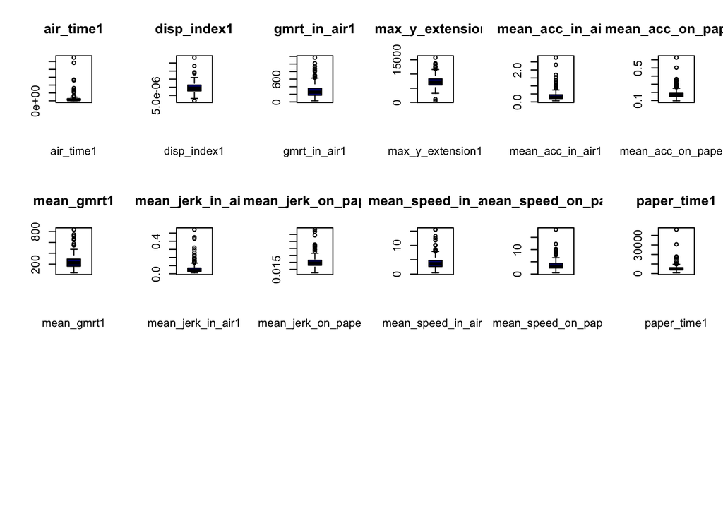

```r
# merge plots onto one figure
par(mfrow=c(3,6))

# Create boxplots of all features
for (i in 1:(ncol(train_data)-1) )
{
  boxplot(train_data[,i], col = "navy", main = colnames(train_data)[i], xlab = colnames(train_data)[i])
}
```

Several high leverage outliers are present in the data, as indicated by the boxplots, significantly skewing the data and masking the true distribution of each feature. Before continuing with further analysis, we will remove these high leverage outliers in an effort to normalize the data. Normalizing the data is crucial for the creation of a predictive model, as it will allow us to better understand the relationship between features and diagnosis. This normalization process is crucial for the creation of a predictive model using linear regression, as one of the fundamental assumptions of linear regression is that the data is normally distributed. After removing the high leverage outliers, we recreate these box plots to better understand the distribution of each feature and to identify the most important predictors of Alzheimer’s disease. Alongside each box plot, we also create a histogram and a distribution plot for every feature.